# Laptops Dataset

# Introduction

**Gaming Laptops** are a very widespread product sold in all parts of the wrold with a huge price varaition and quality variation. we explore today the realtion between price, the reigion, discount, cpu, gpu, ram.

This Dataset was scrapped from Jumia.eg, Amazon.sa, Boulanger.fr

# Intel vs AMD

show the diffrence between sales from intel and from AMD as we can see it seems that there are more intel laptops then there are AMD.

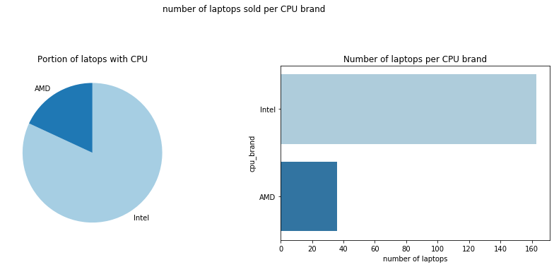

# Comapre the price of Laptops with Intel Based CPU vs AMD based CPU

Intel and AMD seem to have the same average price with AMD having a varity in price and Intel having more Outliers

But taking another Look at the Data while splitting every CPU generation alone.

it seems that Intel Laptops with 9th gen CPU are much more expensive then there AMD counterpart

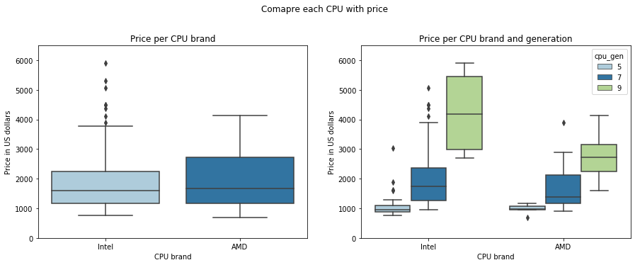

[figure not shown]

# Preform Liner Regression Model to Predict Price

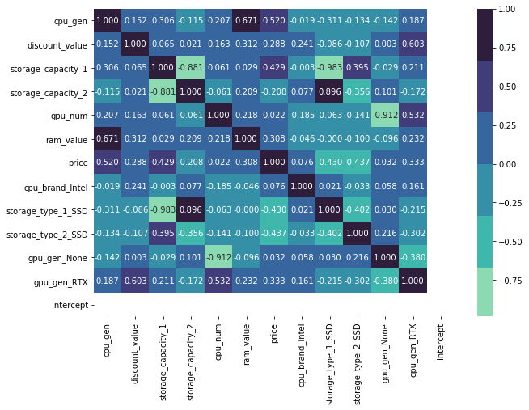

[figure not shown]

Model Summary

| Model: | OLS | Adj. R-squared: | 0.763 |
| --- | --- | --- | --- |
| Dependent Variable: | price | AIC: | 502.8025 |
| Date: | 2021-08-04 16:51 | BIC: | 521.8047 |
| No. Observations: | 36 | Log-Likelihood: | -239.40 |
| Df Model: | 11 | F-statistic: | 11.22 |
| Df Residuals: | 24 | Prob (F-statistic): | 5.68e-07 |
| R-squared: | 0.837 | Scale: | 52452. |

|  | Coef. | Std.Err. | t | P>\|t\| | [0.025 | 0.975] |
| --- | --- | --- | --- | --- | --- | --- |
| cpu_gen | 26.7694 | 67.7007 | 0.3954 | 0.6960 | -112.9581 | 166.4968 |
| discount_value | 5.3377 | 5.6752 | 0.9405 | 0.3563 | -6.3752 | 17.0507 |
| storage_capacity_1 | 0.3237 | 0.7903 | 0.4096 | 0.6857 | -1.3074 | 1.9548 |
| storage_capacity_2 | 0.9922 | 0.3732 | 2.6588 | 0.0137 | 0.2220 | 1.7623 |
| gpu_num | 0.1426 | 0.1870 | 0.7626 | 0.4531 | -0.2433 | 0.5285 |
| ram_value | 4.9164 | 18.8084 | 0.2614 | 0.7960 | -33.9022 | 43.7351 |
| cpu_brand_Intel | 80.3849 | 155.2213 | 0.5179 | 0.6093 | -239.9762 | 400.7460 |
| storage_type_1_SSD | -1291.7134 | 590.9603 | -2.1858 | 0.0388 | -2511.3955 | -72.0312 |
| storage_type_2_SSD | -794.5141 | 121.5117 | -6.5386 | 0.0000 | -1045.3019 | -543.7262 |
| gpu_gen_None | 332.9597 | 288.8319 | 1.1528 | 0.2604 | -263.1600 | 929.0794 |
| gpu_gen_RTX | -262.0193 | 220.6039 | -1.1877 | 0.2466 | -717.3234 | 193.2848 |
| intercept | 575.8472 | 874.5659 | 0.6584 | 0.5165 | -1229.1682 | 2380.8626 |

| Omnibus: | 7.184 | Durbin-Watson: | 1.866 |
| --- | --- | --- | --- |
| Prob(Omnibus): | 0.028 | Jarque-Bera (JB): | 6.090 |
| Skew: | 0.985 | Prob(JB): | 0.048 |
| Kurtosis: | 3.419 | Condition No.: | 40366 |

# hypothesis testing

## Hypothesis 1

it is comman to think that in contries with less curency value Big companies sell on average cheaper products. we will test this hypothesis using Bootstaping and P-values.

### Null Hypothesis

$H0: \mu$ <sub>Egypt</sub> >= $\mu$ <sub>Saudi</sub> or $\mu$ <sub>Saudi</sub> - $\mu$ <sub>Egypt</sub> > 0

### Alternative Hypothesis

$H1: \mu$ <sub>Egypt</sub> < $\mu$ <sub>Saudi</sub> or $\mu$ <sub>Saudi</sub> - $\mu$ <sub>Egypt</sub> <= 0

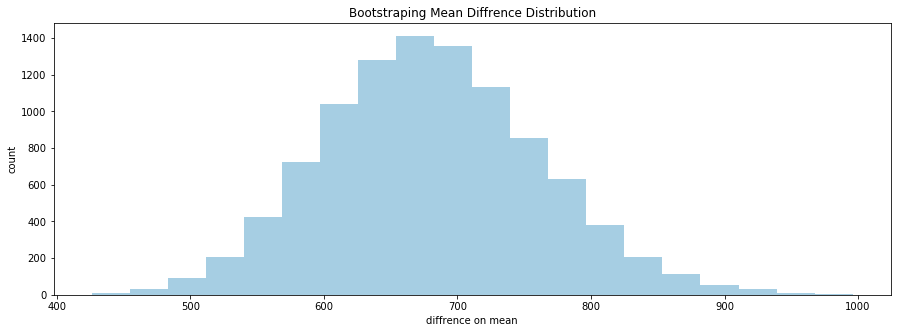

```
P-value= 0.0 of 1 sided Hypothesis test to the right of the observed mean
```

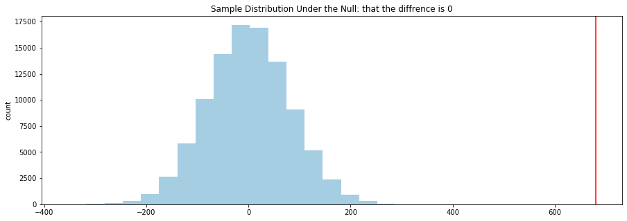

## Hypothesis 2

it is comman to think that in contries with less curency value Big companies sell on average cheaper products. we will test this hypothesis using Bootstaping and P-values.

### Null Hypothesis

$H0: \mu$ <sub>Saudi</sub> >= $\mu$ <sub>France</sub> or $\mu$ <sub>France</sub> - $\mu$ <sub>Saudi</sub> > 0

### Alternative Hypothesis

$H1: \mu$ <sub>Saudi</sub> < $\mu$ <sub>France</sub> or $\mu$ <sub>France</sub> - $\mu$ <sub>Saudi</sub> <= 0

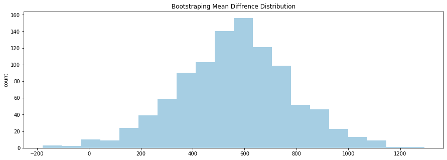

```
P-value= 0.00554 of 1 sided Hypothesis test to the right of the observed mean
```

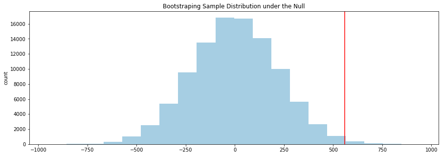

## Conclustion

which means that the average price of Laptops in france exeeds that of Egypt and Saudi Arabia.

# Price vs Discount

Here I am looking at wheather there are any trends between the price of a laptop and discounted value on it. also looking at this relative to each store

There does not seem to be a relation between Price and discount

There is a relation between the store and the price and discount as Boulanger (FR) has higher prices but also higher discounts comapre to Jumia (EG)

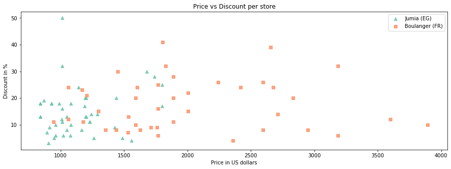

# GPU generation VS CPU

As you know Gaming requires both GPU and CPU. the Nivida GPU are categorized into 2 categorize RTX, GTX with the former being the stronger more expensive one

here we see the frequency where each cpu Generation is paired with a gpu generation

[figure not shown]

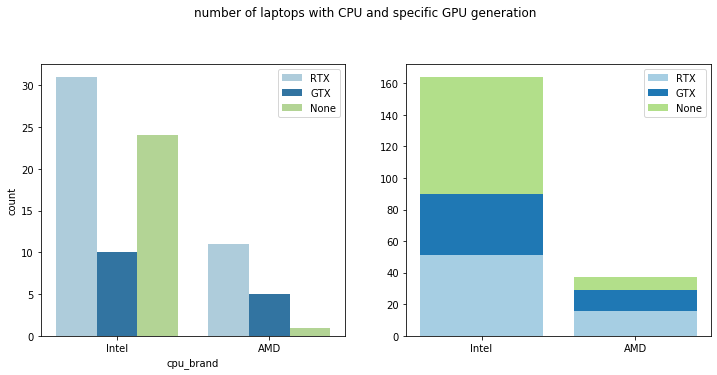

## the average price for each combination of CPU and GPU generations

it is clear that the RTX with 9th gen is the most impressive but what I think is worth noting is that 9th Gen Cpu without a GPU actually come in second place. which shows that most of the price diffrence is due to the CPU

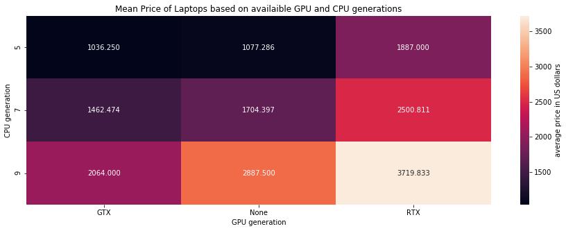

this plot shows a huge **limitation** with the above analysis as the data is pretty concentrated in some categories and very sparse in others.

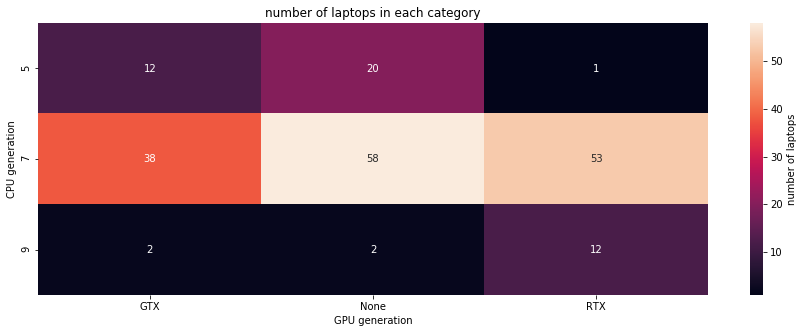